# Final Exam

Ananth Josyula

Due Date: 2022/12/14 @ 11:59PM CST

## Getting Set Up

Download the zipped `DS1000_final_exam.zip` folder from Github and save to your class folder for DS1000. Unzip it, retaining the folder structure. Within you should fine a `code` folder and a `data` folder. The `data` folder should contain the four datasets we will be using in the midterm: `trump_tweet_words.Rds`, `nrc.Rds`, `game_summary.Rds`, and `COVID.Death.Voting.Rds`. Within the `code` folder is this very file: `DS1000_final_exam.Rmd`.

Rename this file to `[LAST NAME]_final.Rmd` and do all your work in this file.

## Grading Requirements (READ CAREFULLY)

Please answer **two** of the following three questions. You may also answer the third question for 10 extra credit points. **If you answer all 3 questions**, please indicate which **two** questions are the final exam submissions, and which **third** question is your intended extra credit. Note that question 2 has an additional 5 points extra credit, but that this is also the hardest exam question.

All of the following questions should be answered with `set.seed(123)`. You will need the following packages:

- `tidyverse`
- `tidymodels`

**NB**: you will be penalized 1 point for each poorly labeled figure. You will be penalized 5 points if the submission is not a PDF of the knitted output. The total points available are 50, + 10 extra credit points if you answer all 3 questions, and + 15 extra credit points if you make question 2 one of your main submissions.

## Question 0: Independent Work Statement

Please sign your name in the space provided by typing out your full name in place of the underline:

“I, Ananth Josyula, am aware of the serious nature of plagiarism and affirm that I did not collaborate with other students while completing this final exam.”

## Question 1 [25 points]

You are hired by the Boston Celtics to advise them on what type of trainer to hire. The **goal** of the Celtics is to increase their away winning percent by 10 percentage points. They only can hire one additional trainer, but each trainer only specializes in one part of the game of basketball: offensive rebounds (`oreb`), free throw shooting (`pctFT`), field goal shooting (`pctFG`), and turnovers (`tov`). Each trainer’s cost starts at $150,000 is increasingly linearly as follows:

- `oreb` trainer: +$1,000 per additional rebound
- `tov` trainer: +$3,000 per reduced turnover
- `pctFT` trainer: +$2,000 per additional percentage point
- `pctFG` trainer: +$5,000 per additional percentage point

Using the `game_summary.Rds` data, create an accurate prediction model for wins / losses, which you should then use to advise the Celtics on which trainer to hire in order to achieve their **goal** while minimizing costs.

The best answers to this question will:

1. Identify missingness in the data, and visualize the variables of interest using univariate and multivariate visualization, wrangling the data as necessary [5 points] **HINT**: [Topic 6](https://github.com/jbisbee1/DS1000-F2022#6-univariate-data-visualization) & [Topic 7](https://github.com/jbisbee1/DS1000-F2022#7-conditional-relationships--visualization)
2. Evaluate and compare two models (linear regression and logistic regression) in terms of AUC using cross validation (100 times with 80-20% split) [5 points] **HINT**: [CV AUC Slides](https://www.jamesbisbee.com/DS1000-F2022/Lectures/Topic10_Classification/code/Topic10_Classification_part3_slides.html#23) & [CV AUC Lecture](https://brightspace.vanderbilt.edu/d2l/le/content/386825/viewContent/2589984/View)
3. Determine the optimal threshold for predicting wins and losses [5 points] **HINT**: [Optimal Threshold](https://www.jamesbisbee.com/DS1000-F2022/Lectures/Topic10_Classification/code/Topic10_Classification_review_slides.html#9)
4. Apply the best-performing model to a hypothetical dataset to demonstrate that focusing on the proposed area of the game will achieve the desired result [5 points] **HINT**: [Consulting](https://www.jamesbisbee.com/DS1000-F2022/Lectures/Topic10_Classification/code/Topic10_Classification_part3_slides.html#56)
5. Clearly describe each step, and justify the final advice [5 points]

```r
# INSERT CODE HERE
#setup
require(tidyverse)
require(tidymodels)
require(tidytext)

gms <- readRDS('../data/game_summary.Rds')

set.seed(123)

summary(gms)
```

```
##      idGame           yearSeason      dateGame              idTeam
##  Min.   :21600001   Min.   :2017   Min.   :2016-10-25   Min.   :1.611e+09
##  1st Qu.:21600923   1st Qu.:2017   1st Qu.:2017-03-04   1st Qu.:1.611e+09
##  Median :21700616   Median :2018   Median :2018-01-11   Median :1.611e+09
##  Mean   :21700616   Mean   :2018   Mean   :2018-01-13   Mean   :1.611e+09
##  3rd Qu.:21800308   3rd Qu.:2019   3rd Qu.:2018-11-28   3rd Qu.:1.611e+09
##  Max.   :21801230   Max.   :2019   Max.   :2019-04-10   Max.   :1.611e+09
##    nameTeam         locationGame            tov             pts
##  Length:7380        Length:7380        Min.   : 2.00   Min.   : 64.0
##  Class :character   Class :character   1st Qu.:11.00   1st Qu.: 99.0
##  Mode  :character   Mode  :character   Median :13.00   Median :108.0
##                                        Mean   :13.53   Mean   :107.7
##                                        3rd Qu.:16.00   3rd Qu.:116.0
##                                        Max.   :29.00   Max.   :168.0
##       treb            oreb           pctFG            pctFT
##  Min.   :22.00   Min.   : 0.00   Min.   :0.2009   Min.   :0.1112
##  1st Qu.:40.00   1st Qu.: 7.00   1st Qu.:0.3985   1st Qu.:0.6833
##  Median :44.00   Median :10.00   Median :0.4450   Median :0.7641
##  Mean   :44.07   Mean   :10.07   Mean   :0.4472   Mean   :0.7581
##  3rd Qu.:48.00   3rd Qu.:12.00   3rd Qu.:0.4941   3rd Qu.:0.8438
##  Max.   :71.00   Max.   :26.00   Max.   :0.7006   Max.   :1.0000
##     teamrest       second_game       isWin             ft_80
##  Min.   :  0.000   Mode :logical   Mode :logical   Min.   :0.0000
##  1st Qu.:  1.000   FALSE:6058      FALSE:3690      1st Qu.:0.0000
##  Median :  1.000   TRUE :1322      TRUE :3690      Median :0.0000
##  Mean   :  2.579                                   Mean   :0.3797
##  3rd Qu.:  1.000                                   3rd Qu.:1.0000
##  Max.   :120.000                                   Max.   :1.0000
```

```r
gms <- gms %>%
  filter(nameTeam == "Boston Celtics")

gms %>%
  group_by(nameTeam)
```

```
## # A tibble: 246 × 16
## # Groups:   nameTeam [1]
##      idGame yearSeason dateGame   idTeam nameT…¹ locat…²   tov   pts  treb  oreb
##       <dbl>      <int> <date>      <dbl> <chr>   <chr>   <dbl> <dbl> <dbl> <dbl>
##  1 21600006       2017 2016-10-26 1.61e9 Boston… H          19   122    47    12
##  2 21600015       2017 2016-10-27 1.61e9 Boston… A          11    99    36     3
##  3 21600027       2017 2016-10-29 1.61e9 Boston… A          13   104    42     4
##  4 21600061       2017 2016-11-02 1.61e9 Boston… H          12   107    39    10
##  5 21600068       2017 2016-11-03 1.61e9 Boston… A           8   122    39    10
##  6 21600091       2017 2016-11-06 1.61e9 Boston… H          11   107    39    11
##  7 21600107       2017 2016-11-09 1.61e9 Boston… A          11    93    31     7
##  8 21600125       2017 2016-11-11 1.61e9 Boston… H          15   115    53    19
##  9 21600130       2017 2016-11-12 1.61e9 Boston… A          13   105    47    15
## 10 21600148       2017 2016-11-14 1.61e9 Boston… A          10   105    44    11
## # … with 236 more rows, 6 more variables: pctFG <dbl>, pctFT <dbl>,
## #   teamrest <dbl>, second_game <lgl>, isWin <lgl>, ft_80 <dbl>, and
## #   abbreviated variable names ¹nameTeam, ²locationGame
```

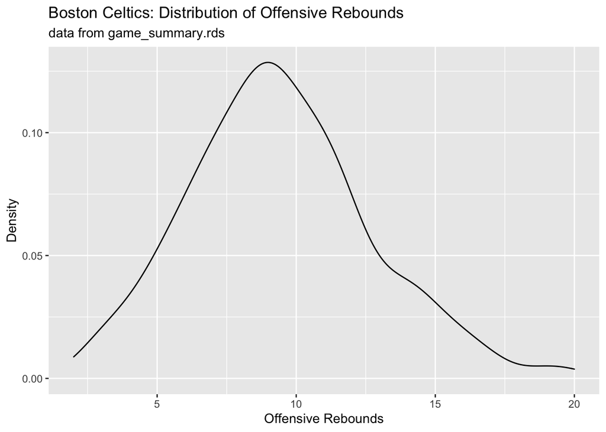

```r
#1. Identify missingness in the data, and visualize the variables of interest using univariate and multivariate visualization, wrangling the data as necessary [5 points]

#Univariate continuous integer data so distribution density curve
gms %>%
  ggplot(aes(x=oreb))+
  geom_density()+
  labs(title = 'Boston Celtics: Distribution of Offensive Rebounds',
       subtitle = "data from game_summary.rds",
       x='Offensive Rebounds',
       y='Density')
```

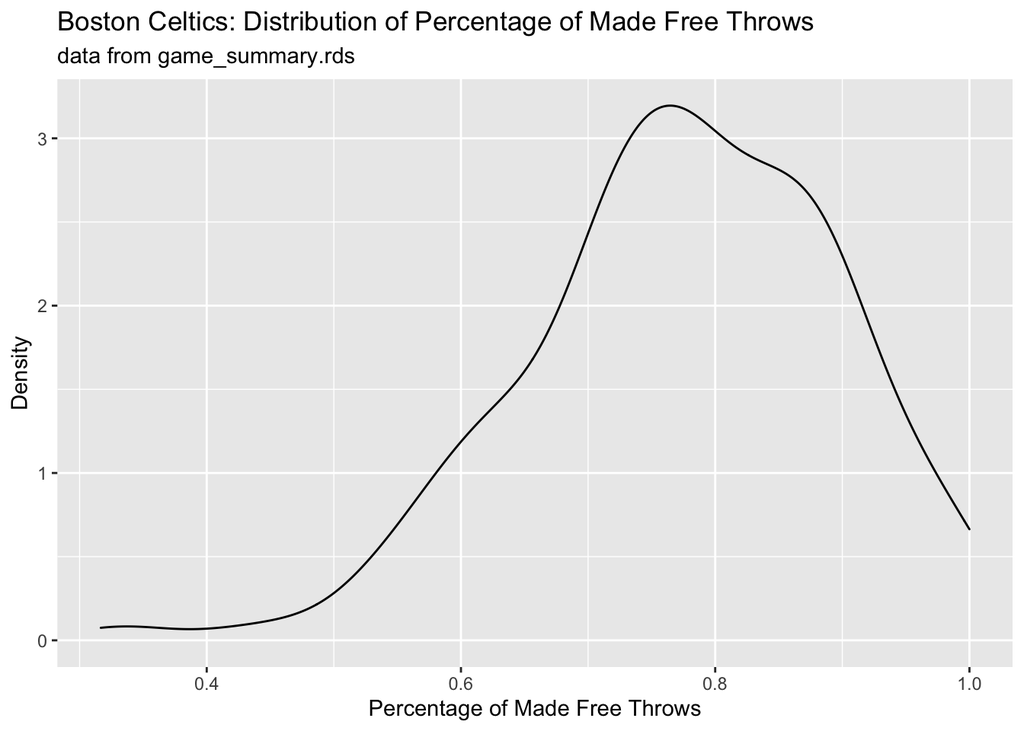

```r
#Univariate continuous data so distribution density curve
gms %>%
  ggplot(aes(x=pctFT))+
  geom_density()+
  labs(title = 'Boston Celtics: Distribution of Percentage of Made Free Throws',
       subtitle = "data from game_summary.rds",
       x='Percentage of Made Free Throws',
       y='Density')
```

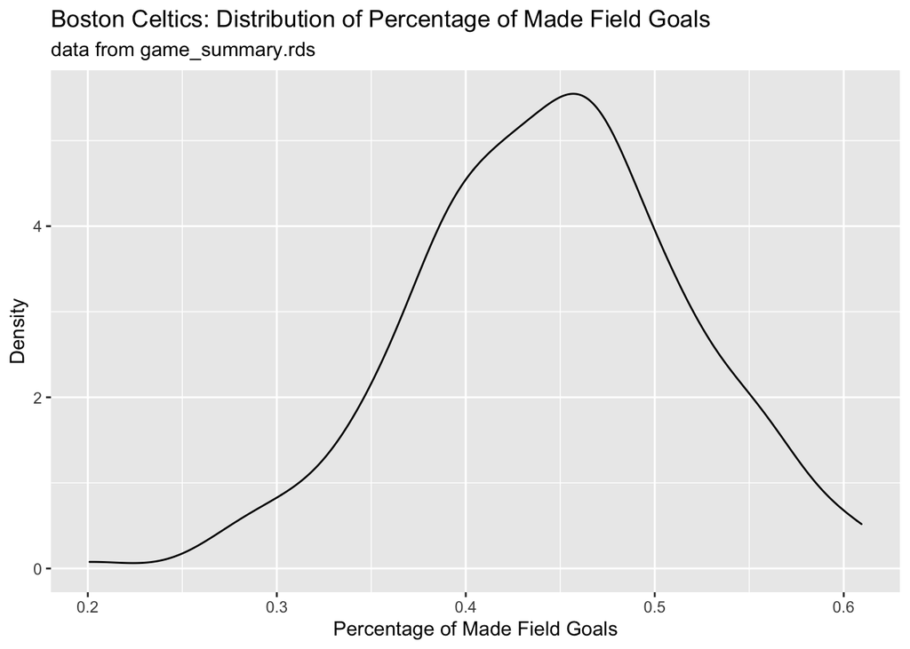

```r
#Univariate continuous data so distribution density curve
gms %>%
  ggplot(aes(x=pctFG))+
  geom_density()+
  labs(title = 'Boston Celtics: Distribution of Percentage of Made Field Goals',
       subtitle = "data from game_summary.rds",
       x='Percentage of Made Field Goals',
       y='Density')
```

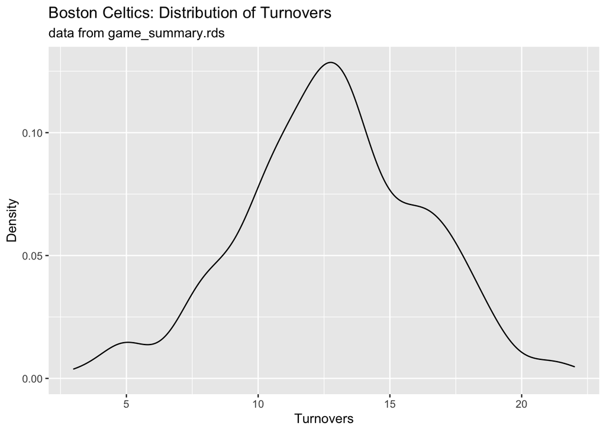

```r
#Univariate continuous integer data so distribution density curve
gms %>%
  ggplot(aes(x=tov))+
  geom_density()+
  labs(title = 'Boston Celtics: Distribution of Turnovers',
       subtitle = "data from game_summary.rds",
       x='Turnovers',
       y='Density')
```

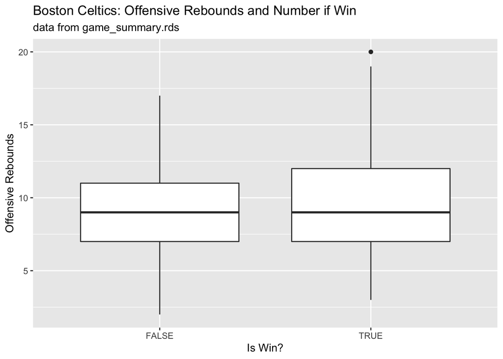

```r
#Multivariate data so boxplot
gms %>%
  ggplot(aes(x=isWin, y=oreb))+
  geom_boxplot()+
  labs(title = 'Boston Celtics: Offensive Rebounds and Number if Win',
       subtitle = "data from game_summary.rds",
       x='Is Win?',
       y='Offensive Rebounds')
```

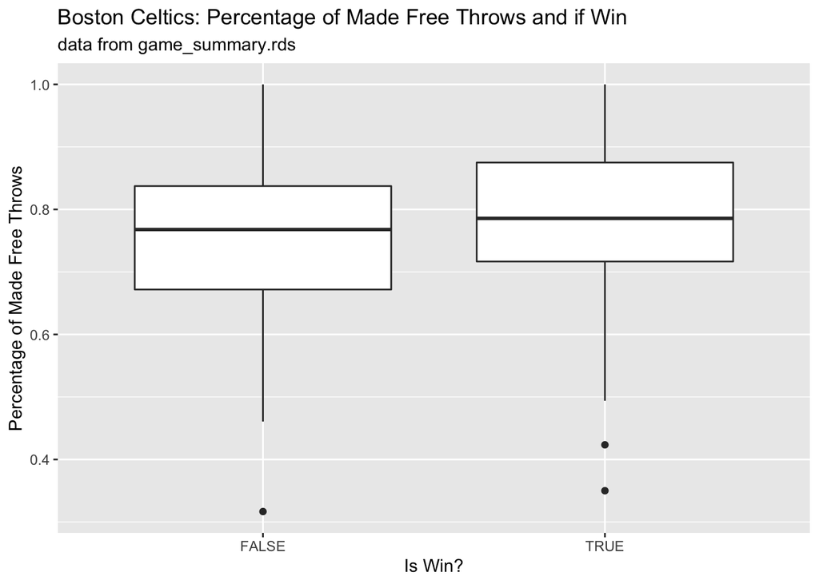

```r
#Multivariate data so boxplot
gms %>%
  ggplot(aes(x=isWin, y=pctFT))+
  geom_boxplot()+
  labs(title = 'Boston Celtics: Percentage of Made Free Throws and if Win',
       subtitle = "data from game_summary.rds",
       x='Is Win?',
       y='Percentage of Made Free Throws')
```

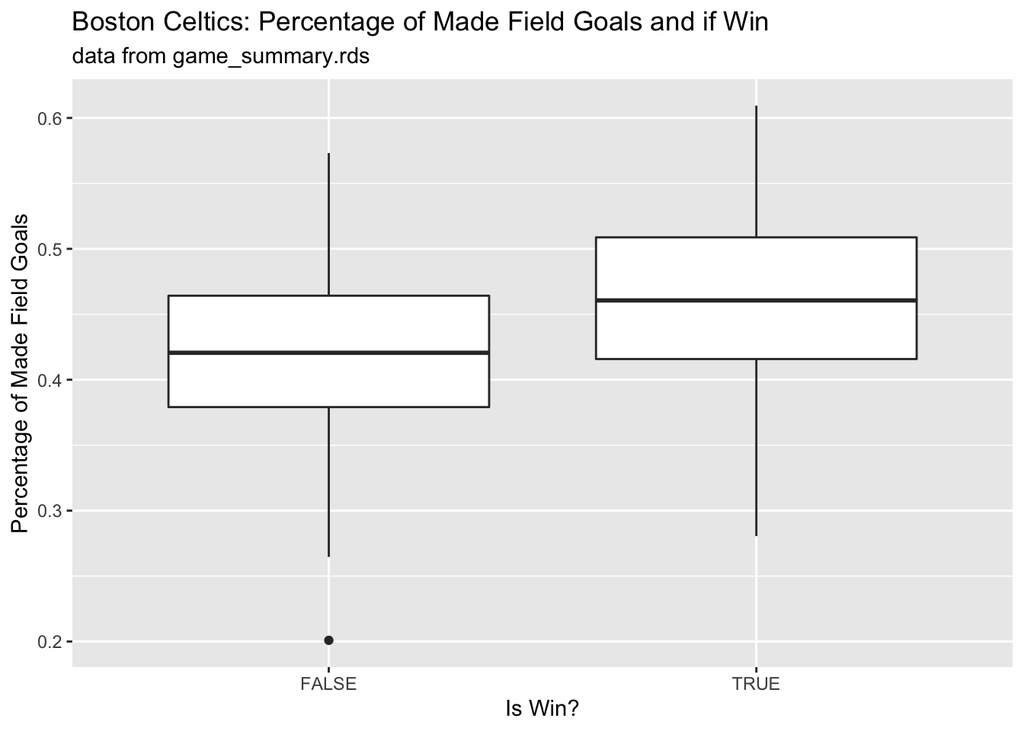

```r
#Multivariate data so boxplot
gms %>%
  ggplot(aes(x=isWin, y=pctFG))+
  geom_boxplot()+
  labs(title = 'Boston Celtics: Percentage of Made Field Goals and if Win',
       subtitle = "data from game_summary.rds",
       x='Is Win?',
       y='Percentage of Made Field Goals')
```

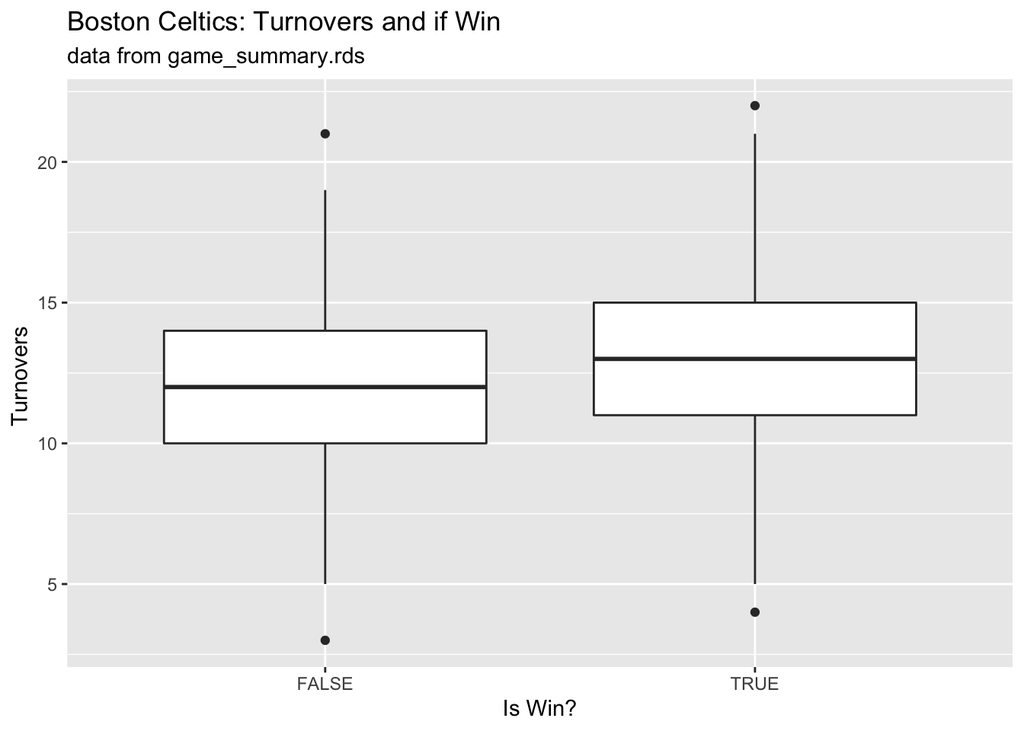

```r
#Multivariate data so boxplot
gms %>%
  ggplot(aes(x=isWin, y=tov))+
  geom_boxplot()+
  labs(title = 'Boston Celtics: Turnovers and if Win',
       subtitle = "data from game_summary.rds",
       x='Is Win?',
       y='Turnovers ')
```

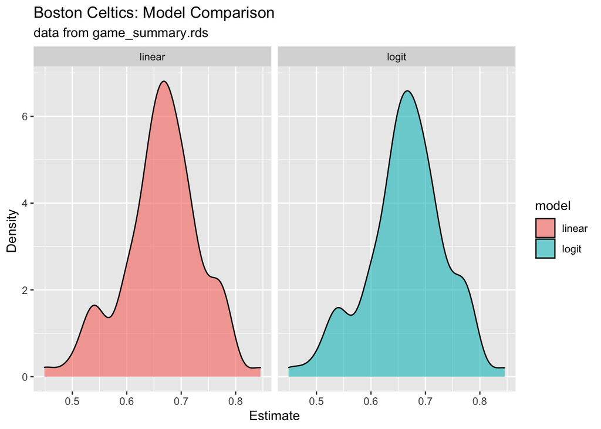

```r
#2. Evaluate and compare two models (linear regression and logistic regression) in terms of AUC using cross validation (100 times with 80-20% split) [5 points]

compRes <- NULL

for(i in 1:100) {
  inds <- sample(1:nrow(gms),size = round(nrow(gms)*0.8),replace = F)
  train <- gms %>% slice(inds)
  test <- gms %>% slice(-inds)

  mLM <- lm(isWin ~ oreb + tov + pctFT + pctFG, train)
  mLG <- glm(isWin ~ oreb + tov + pctFT + pctFG, data = train, family = binomial(link = 'logit'))

  #Predict both models
  pred <- test %>%
    mutate(predLM = predict(mLM,newdata = test),
           predLG = predict(mLG,newdata = test,type = 'response'),
           truth = factor(isWin,levels = c('TRUE','FALSE')))

  #Evaluate both models
  resLG <- roc_auc(data = pred,truth = 'truth',estimate = 'predLG') %>%
    mutate(model = 'logit')
  resLM <- roc_auc(data = pred,truth = 'truth',estimate = 'predLM') %>%
    mutate(model = 'linear')
  compRes <- resLG %>% bind_rows(resLM) %>% bind_rows(compRes)
}

#Graph both models
compRes %>%
  ggplot(aes(x=.estimate,fill = model))+
  geom_density(alpha = 0.6)+
  labs(title = 'Boston Celtics: Model Comparison',
       subtitle = "data from game_summary.rds",
       x='Estimate',
       y='Density ')+
  facet_wrap(~model)
```

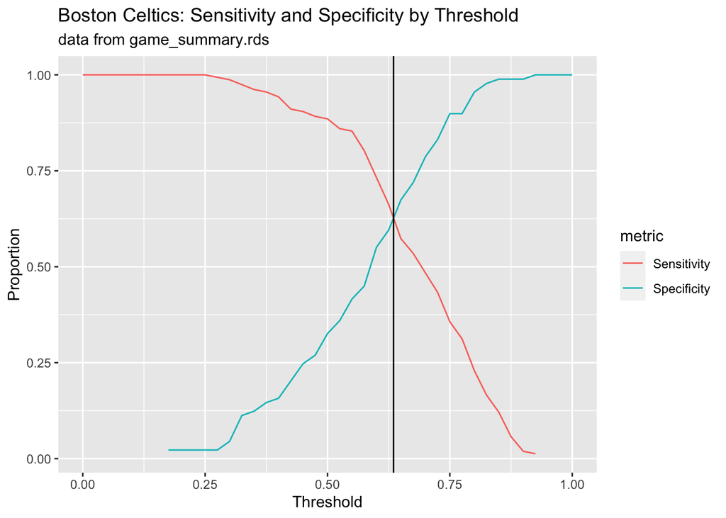

```r
#3. Determine the optimal threshold for predicting wins and losses [5 points]

#Train
mLG <- glm(isWin ~ tov + oreb + pctFT + pctFG, gms, family = binomial(link = 'logit'))

toplot <- NULL
for(thresh in seq(0,1,by = 0.025)) {
  toplot <- gms %>%
    mutate(predWins = ifelse(predict(mLG, type = 'response') > thresh,1,0)) %>%
    group_by(isWin) %>%
    mutate(totalWins = n()) %>%
    group_by(isWin,predWins,totalWins) %>%
    summarise(numGames=n(),.groups = 'drop') %>%
    mutate(prop = numGames / totalWins) %>%
    mutate(threshold = thresh) %>%
    bind_rows(toplot)
}

#Plot optimal threshold
toplot %>%
  mutate(metric = ifelse(isWin == TRUE & predWins == 1, 'Sensitivity',
                         ifelse(isWin == FALSE & predWins == 0, 'Specificity', NA))) %>%
  drop_na(metric) %>%
  ggplot(aes(x=threshold,
             y=prop,
             color=metric)) +
  geom_line()+
  geom_vline(xintercept = .635) +
  labs(title = "Boston Celtics: Sensitivity and Specificity by Threshold",
       subtitle = "data from game_summary.rds",
       x = "Threshold",
       y = "Proportion")
```

## Question 2 [25 points + 5 EC]

Using the `trump_tweet_words.Rds` data, combined with the `nrc.Rds` data, investigate the following research question: “Did the sentiment of Trump’s tweets influence their popularity?”

The best answers to this question will:

1. Articulate a theory and a hypothesis in response to the question [5 points] [Theory matters!](https://www.jamesbisbee.com/DS1000-F2022/Lectures/Topic4_DataWrangling/code/Topic4_DataWrangling_part2_slides.html#23)
2. Merge the Trump tweet data with the NRC sentiment data using `inner_join()`, then calculate the net sentiment per tweet using a combination of `group_by()` + `summarise()`, `spread()`, and `mutate()` [5 points] **HINT**: [2022/11/07 content](https://github.com/jbisbee1/DS1000-F2022#9--clustering-text-twitter-and-sentiment). This doesn’t require a written explanation from point 5 below.
3. Visualize the variables of interest using univariate and multivariate visualization, and wrangle the data as necessary [5 points] **HINT**: [Topic 6](https://github.com/jbisbee1/DS1000-F2022#6-univariate-data-visualization) & [Topic 7](https://github.com/jbisbee1/DS1000-F2022#7-conditional-relationships--visualization)
4. Run a linear regression model and evaluate in terms of both RMSE (via 100 cross validation with an 80-20 split) and visual analysis of the errors (both univariate visualization of the errors and multivariate visualization of the errors versus the net sentiment) [5 points] **HINT**: [RMSE CV](https://www.jamesbisbee.com/DS1000-F2022/Lectures/Topic8_Regression/code/Topic8_Regression_part2_slides.html#47) & [Error analysis](https://brightspace.vanderbilt.edu/d2l/le/content/386825/viewContent/2563389/View)
5. Clearly describe each step, and interpret the final regression model in light of the research question. What should you potentially add to the $X$ variables as a control to improve the model? [5 points]
6. Re-run the model with the control added, and re-evaluate the errors (again, using both univariate and multivariate) [5 EC points]

```r
# INSERT CODE HERE
#Load
nrc <- readRDS('../data/nrc.Rds')
trump <- readRDS(file="../data/Trump_tweet_words.Rds")

nrc <- nrc %>%
  filter(sentiment %in% c('positive','negative'))

#2. Merge the Trump tweet data with the NRC sentiment data using `inner_join()`, then calculate the net sentiment per tweet using a combination of `group_by()` + `summarise()`, `spread()`, and `mutate()` [5 points]

trumpNRC <- trump %>%
  inner_join(nrc)

trumpSentiment <- trumpNRC %>%
  group_by(document,retweets) %>%
  count(sentiment) %>%
  ungroup() %>%
  spread(sentiment,n,fill = 0) %>%
  mutate(netSentiment = positive - negative)

nrc <- get_sentiments('nrc')

trumpSentiment %>%
  select(document,retweets,netSentiment)
```

```
## # A tibble: 30,454 × 3
##      document retweets netSentiment
##         <dbl>    <dbl>        <dbl>
##  1 1698308935      500            0
##  2 1701461182       33            1
##  3 1737479987       12            0
##  4 1741160716       11            0
##  5 1773561338     1399            1
##  6 1786560616       14            1
##  7 1796477499       18            2
##  8 1806258917       14            1
##  9 1826225450       38           -1
## 10 1884022748       12            0
## # … with 30,444 more rows
```

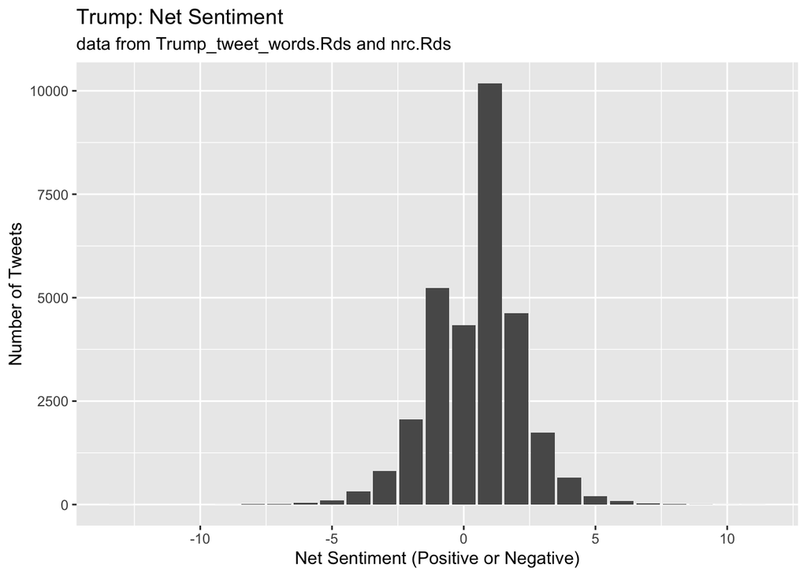

```r
#2. Visualize the variables of interest using univariate and multivariate visualization, and wrangle the data as necessary [5 points]

#Univariate visualization of net sentiment
trumpSentiment %>%
  ggplot(aes(x = netSentiment)) +
  geom_bar() +
  labs(title = 'Trump: Net Sentiment',
       subtitle = 'data from Trump_tweet_words.Rds and nrc.Rds',
       x='Net Sentiment (Positive or Negative)',
       y='Number of Tweets')
```

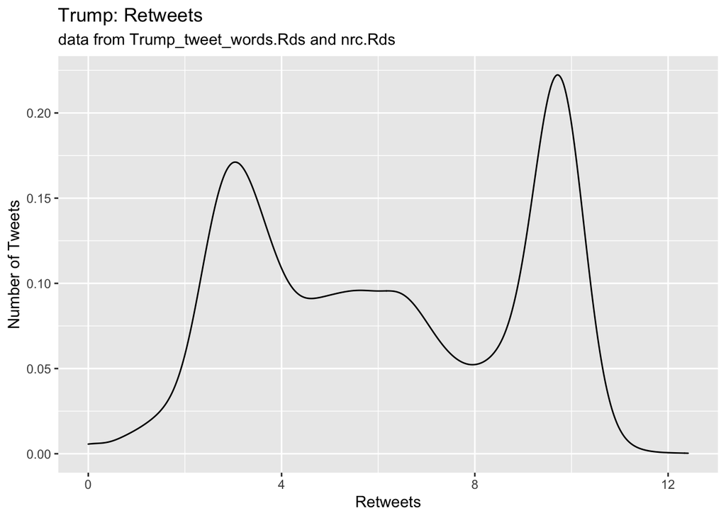

```r
#Univariate visualization of retweets
trumpSentiment %>%
  mutate(logRetweets = log(retweets+1))%>%
  ggplot(aes(x = logRetweets)) +
  geom_density()+
  labs(title = 'Trump: Retweets',
       subtitle = 'data from Trump_tweet_words.Rds and nrc.Rds',
       x='Retweets',
       y='Number of Tweets')
```

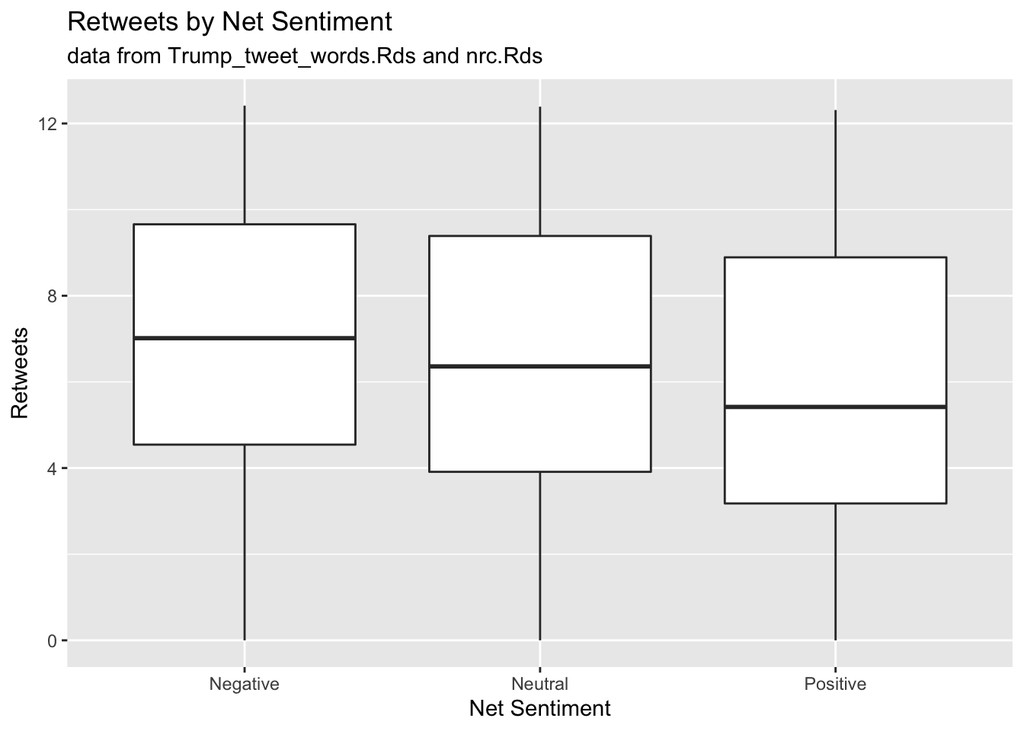

```r
#Multivariate visualization
trumpSentiment %>%
  mutate(posSent = ifelse(netSentiment < 0,
                          'Negative',
                          ifelse(netSentiment > 0,
                                 'Positive','Neutral')),
         logRetweets = log(retweets+1)) %>%
  ggplot(aes(x = posSent, y = logRetweets)) +
  geom_boxplot() +
  labs(title = 'Retweets by Net Sentiment',
       subtitle = 'data from Trump_tweet_words.Rds and nrc.Rds',
       x='Net Sentiment',
       y='Retweets')
```

```r
#4. Run a linear regression model and evaluate in terms of both RMSE (via 100 cross validation with an 80-20 split) and visual analysis of the errors (both univariate visualization of the errors and multivariate visualization of the errors versus the net sentiment) [5 points]

#RMSE
trumpFinal <- trumpSentiment %>%
  mutate(logRetweets = log(retweets + 1)) %>%
  drop_na()

set.seed(123)

rmseCV <- NULL
for(i in 1:100) {
  inds <- sample(1:nrow(trumpFinal),size = round(nrow(trumpFinal)*0.8),replace = F)
  train <- trumpFinal %>% slice(inds)
  test <- trumpFinal %>% slice(-inds)
  mTrain <- lm(logRetweets ~ netSentiment,train)
  rmseCV <- test %>%
    mutate(preds = predict(mTrain,newdata = test)) %>%
    summarise(rmse = sqrt(mean((logRetweets - preds)^2))) %>%
    mutate(index = i) %>%
    bind_rows(rmseCV)
}
mean(rmseCV$rmse)
```

```
## [1] 2.82657
```

```r
#Visual analysis
m <- lm(logRetweets ~ netSentiment,trumpFinal)

summary(m)
```

```
##
## Call:
## lm(formula = logRetweets ~ netSentiment, data = trumpFinal)
##
## Residuals:
##    Min     1Q Median     3Q    Max
## -6.563 -2.626 -0.187  2.894  6.220
##
## Coefficients:
##               Estimate Std. Error t value Pr(>|t|)
## (Intercept)   6.327699   0.016874  375.00   <2e-16 ***
## netSentiment -0.235516   0.009472  -24.86   <2e-16 ***
## ---
## Signif. codes:  0 '***' 0.001 '**' 0.01 '*' 0.05 '.' 0.1 ' ' 1
##
## Residual standard error: 2.828 on 30452 degrees of freedom
## Multiple R-squared:  0.0199, Adjusted R-squared:  0.01987
## F-statistic: 618.2 on 1 and 30452 DF,  p-value: < 2.2e-16
```

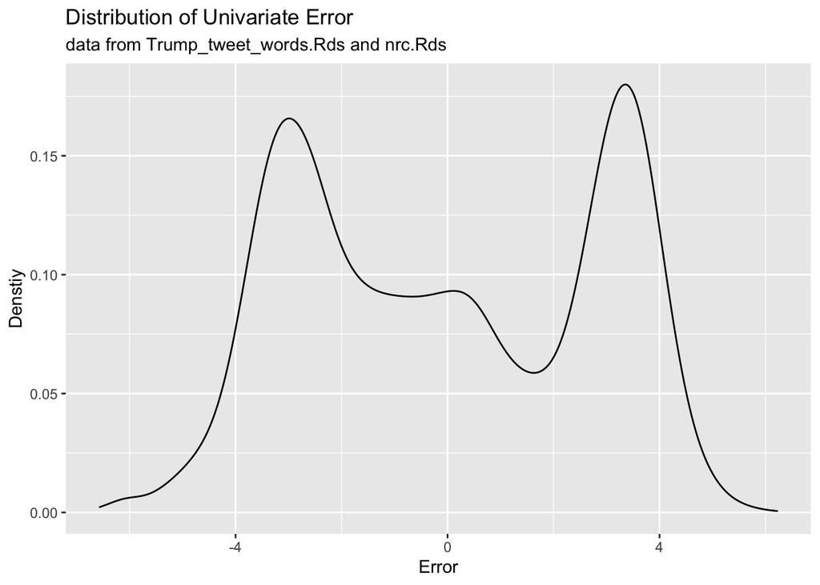

```r
trumpFinal <- trumpFinal %>%
  ungroup() %>%
  mutate(preds = predict(m)) %>%
  mutate(errors = logRetweets - preds)

trumpFinal %>%
  ggplot(aes(x = errors)) +
  geom_density()+
  labs(title = 'Distribution of Univariate Error',
       subtitle = 'data from Trump_tweet_words.Rds and nrc.Rds',
       x='Error',
       y='Denstiy')
```

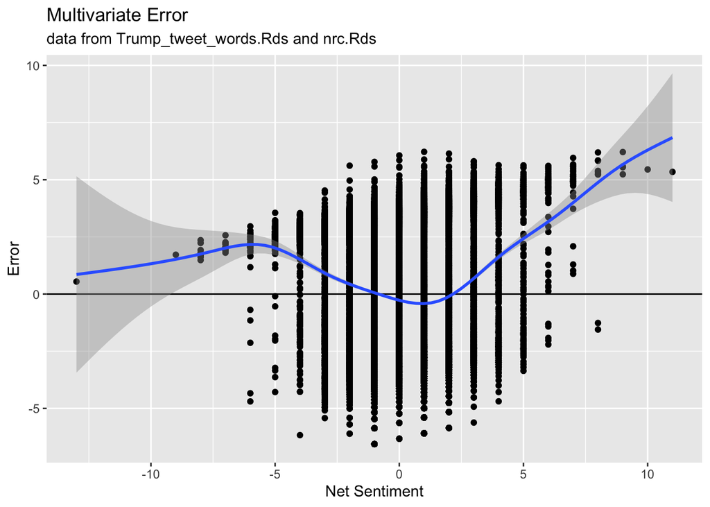

```r
trumpFinal %>%
  ggplot(aes(x = netSentiment,
             y = errors)) +
  geom_point() +
  geom_hline(yintercept=0)+
  geom_smooth()+
  labs(title = 'Multivariate Error',
       subtitle = 'data from Trump_tweet_words.Rds and nrc.Rds',
       x='Net Sentiment',
       y='Error')
```

```r
#6. Re-run the model with the control added, and re-evaluate the errors (again, using both univariate and multivariate) [5 EC points]

trumpSentiment2 <- trumpNRC %>%
  filter(Tweeting.year == "2016" | Tweeting.year == "2017" | Tweeting.year == "2018" | Tweeting.year == "2019"| Tweeting.year == "2020")%>%
  group_by(document,retweets) %>%
  count(sentiment) %>%
  ungroup() %>%
  spread(sentiment,n,fill = 0) %>%
  mutate(netSentiment = positive - negative)
require(tidytext)
nrc <- get_sentiments('nrc')

trumpSentiment2 %>%
  select(document,retweets,netSentiment)
```

```
## # A tibble: 11,080 × 3
##    document retweets netSentiment
##       <dbl>    <dbl>        <dbl>
##  1  6.83e17     1683            1
##  2  6.83e17     2318           -1
##  3  6.83e17      552            3
##  4  6.83e17      755            2
##  5  6.83e17      742           -2
##  6  6.83e17      768            1
##  7  6.83e17     1429            1
##  8  6.83e17      827            1
##  9  6.83e17     1601            1
## 10  6.83e17     1799            1
## # … with 11,070 more rows
```

```r
#RMSE
trumpFinal2 <- trumpSentiment2 %>%
  mutate(logRetweets = log(retweets + 1))%>%
  drop_na()

set.seed(123)
rmseCV2 <- NULL
for(i in 1:100) {
  inds <- sample(1:nrow(trumpFinal2),size = round(nrow(trumpFinal2)*0.8),replace = F)
  train <- trumpFinal2 %>% slice(inds)
  test <- trumpFinal2 %>% slice(-inds)
  mTrain <- lm(logRetweets ~ netSentiment,train)
  rmseCV2 <- test %>%
    mutate(preds = predict(mTrain,newdata = test)) %>%
    summarise(rmse = sqrt(mean((logRetweets - preds)^2))) %>%
    mutate(index = i) %>%
    bind_rows(rmseCV)
}
mean(rmseCV$rmse)
```

```
## [1] 2.82657
```

```r
#Visual analysis
m <- lm(logRetweets ~ netSentiment,trumpFinal2)

summary(m)
```

```
##
## Call:
## lm(formula = logRetweets ~ netSentiment, data = trumpFinal2)
##
## Residuals:
##     Min      1Q  Median      3Q     Max
## -3.2067 -0.2905  0.1774  0.5039  2.9536
##
## Coefficients:
##               Estimate Std. Error t value Pr(>|t|)
## (Intercept)   9.436269   0.007596 1242.29   <2e-16 ***
## netSentiment -0.037615   0.003700  -10.17   <2e-16 ***
## ---
## Signif. codes:  0 '***' 0.001 '**' 0.01 '*' 0.05 '.' 0.1 ' ' 1
##
## Residual standard error: 0.7924 on 11078 degrees of freedom
## Multiple R-squared:  0.009244,   Adjusted R-squared:  0.009155
## F-statistic: 103.4 on 1 and 11078 DF,  p-value: < 2.2e-16
```

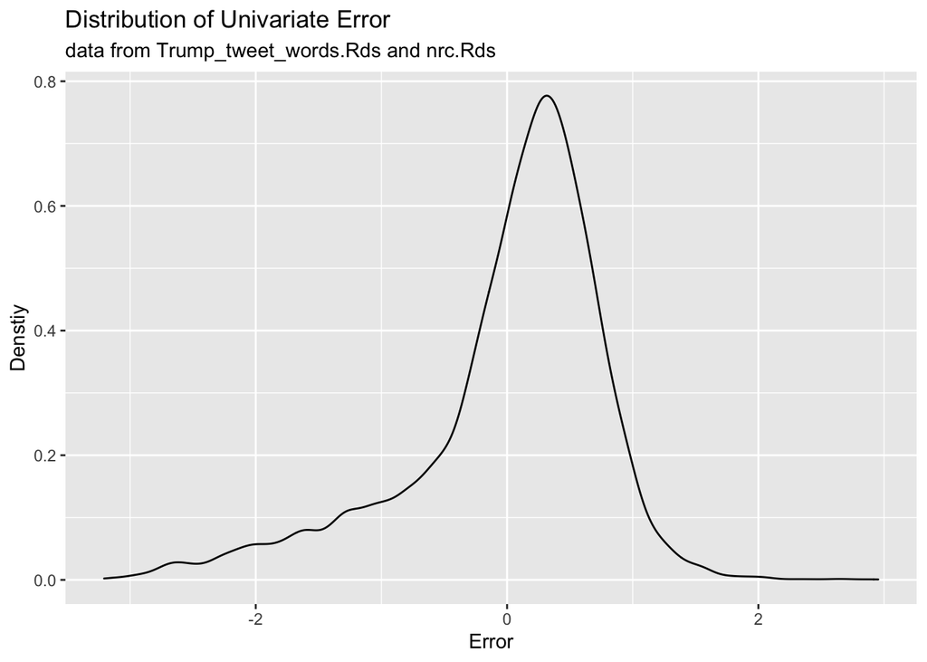

```r
trumpFinal2 <- trumpFinal2 %>%
  ungroup() %>%
  mutate(preds = predict(m)) %>%
  mutate(errors = logRetweets - preds)

trumpFinal2 %>%
  ggplot(aes(x = errors)) +
  geom_density()+
  labs(title = 'Distribution of Univariate Error',
       subtitle = 'data from Trump_tweet_words.Rds and nrc.Rds',
       x='Error',
       y='Denstiy')
```

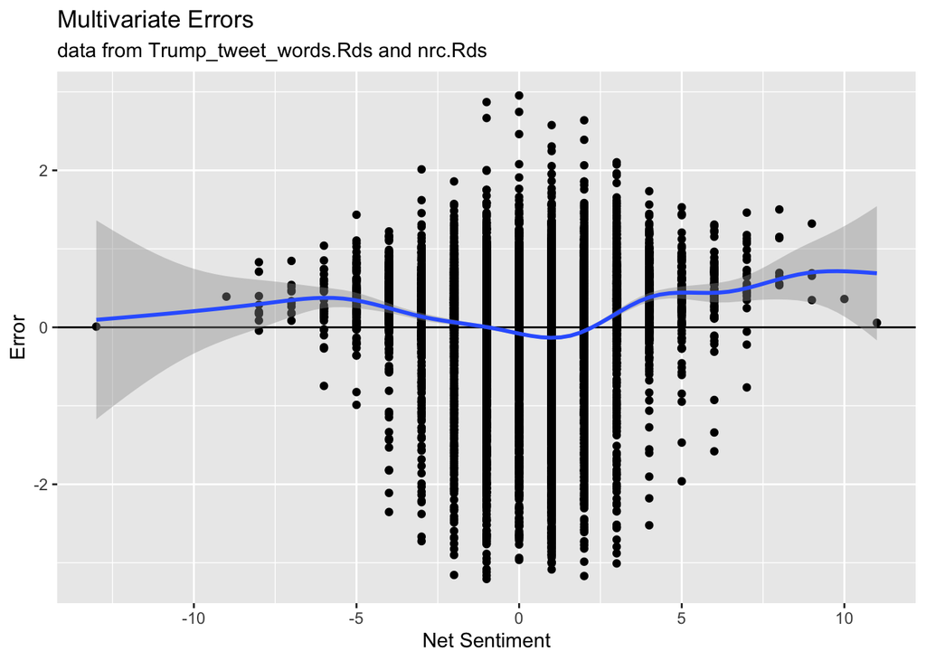

```r
trumpFinal2 %>%
  ggplot(aes(x = netSentiment,
             y = errors)) +
  geom_point() +
  geom_hline(yintercept=0)+
  geom_smooth()+
  labs(title = 'Multivariate Errors',
       subtitle = 'data from Trump_tweet_words.Rds and nrc.Rds',
       x='Net Sentiment',
       y='Error')
```

> - Theory: People are drawn to opinions → Trump’s tweets that are more opinionated will be more popular Hypothesis: If Trump’s tweets’ net sentiment increases, Trump’s tweets will increase in popularity? The results show that we failt to accept the hypothesis since the Retweets by Net Sentiment shows little increase in the number of retweets for “Negative” tweets vs “Neutral” tweets and in fact shows a decrease in the number of retweets for “Positive” tweets vs “Neutral” tweets. Thus, although there may be a correlation between “Negative” tweets having more popular, further testing is necessary. It is also interesting that we did not keep track of whether or not the tweet was made in an election year or not as that might have a significant impact on viewers choosing to retweet in pursuit of their candidate’s election victory. Thus, differentiating between election year tweets and non election year tweets could serve as a control to improve the model.

## Question 3 [25 points]

Using the `COVID.Death.Voting.Rds` file, answer the following research question: “did counties that supported Trump experience more deaths from Covid than counties that supported Biden?”

The best answers to this question will:

1. Write a simple theory and a hypothesis [5 points] **HINT**: [Theory matters!](https://www.jamesbisbee.com/DS1000-F2022/Lectures/Topic4_DataWrangling/code/Topic4_DataWrangling_part2_slides.html#23)
2. Plot the univariate and multivariate distributions of the data, and make any necessary adjustments [5 points] **HINT**: [Topic 6](https://github.com/jbisbee1/DS1000-F2022#6-univariate-data-visualization) & [Topic 7](https://github.com/jbisbee1/DS1000-F2022#7-conditional-relationships--visualization)
3. Run a simple linear regression of the death rate per 100,000 (**NB** you will have to create this variable with `mutate()`) predicted by the proportion of votes for Trump and evaluate in terms of RMSE (100 cross validated iterations with an 80-20 split) and visual analysis of the errors (both univariate and multivariate visualizations, where the latter compares the errors to the $X$ predictor) [5 points] **HINT**: [RMSE CV](https://www.jamesbisbee.com/DS1000-F2022/Lectures/Topic8_Regression/code/Topic8_Regression_part2_slides.html#47) & [Error analysis](https://brightspace.vanderbilt.edu/d2l/le/content/386825/viewContent/2563389/View)
4. Run a more complicated linear regression where you control for population density, the percent of the population that is non-Hispanic white, non-Hispanic black, non-Hispanic Asian, and Hispanic, and the turnout percent, and then re-evaluate RMSE and errors [5 points]
5. Interpret the results in light of the research question [5 points].

```r
# INSERT CODE HERE
```